# Session_4-AnalysingData

# 1 Loading packages

```r
## Use the code below to check if you have all required packages installed. If some are not installed already, the code below will install these. If you have all packages installed, then you could load them with the second code.
requiredPackages = c('ggplot2', 'tidyverse', 'psycho', 'ordinal', 'PresenceAbsence', 'broom', 'emmeans', 'car')
for(p in requiredPackages){
  if(!require(p,character.only = TRUE)) install.packages(p)
  library(p,character.only = TRUE)
}
```

# 2 Basic statistics

## 2.1 Built-in datasets

We will use one of the built in `R`. You can check all available datasets in `R` using the following:

```r
data()
# or below for all datasets available in all installed packages
data(package = .packages(all.available = TRUE))
```

```
datasets have been moved from package 'base' to package 'datasets'datasets have been moved from package 'stats' to package 'datasets'
```

We will use the `iris` dataset from the package `MASS`

## 2.2 Checking structure and summaries

### 2.2.1 Structure

```r
str(iris)
```

```
'data.frame':   150 obs. of  5 variables:
 $ Sepal.Length: num  5.1 4.9 4.7 4.6 5 5.4 4.6 5 4.4 4.9 ...
 $ Sepal.Width : num  3.5 3 3.2 3.1 3.6 3.9 3.4 3.4 2.9 3.1 ...
 $ Petal.Length: num  1.4 1.4 1.3 1.5 1.4 1.7 1.4 1.5 1.4 1.5 ...
 $ Petal.Width : num  0.2 0.2 0.2 0.2 0.2 0.4 0.3 0.2 0.2 0.1 ...
 $ Species     : Factor w/ 3 levels "setosa","versicolor",..: 1 1 1 1 1 1 1 1 1 1 ...
```

We have a dataframe with 150 observations and 5 variables; 4 numeric and 1 factor with 3 levels.

### 2.2.2 Summary

We summarise the data to see the trends:

```r
summary(iris)
```

```
  Sepal.Length    Sepal.Width     Petal.Length    Petal.Width
 Min.   :4.300   Min.   :2.000   Min.   :1.000   Min.   :0.100
 1st Qu.:5.100   1st Qu.:2.800   1st Qu.:1.600   1st Qu.:0.300
 Median :5.800   Median :3.000   Median :4.350   Median :1.300
 Mean   :5.843   Mean   :3.057   Mean   :3.758   Mean   :1.199
 3rd Qu.:6.400   3rd Qu.:3.300   3rd Qu.:5.100   3rd Qu.:1.800
 Max.   :7.900   Max.   :4.400   Max.   :6.900   Max.   :2.500
       Species
 setosa    :50
 versicolor:50
 virginica :50
```

So we have an equal dataframe (50 observations under each level of the factor `Species`), with no missing values (aka `NA`).

### 2.2.3 Advanced

What if you want to summarise the data and get the mean, SD, by each level of the factor?

```r
iris %>%
  group_by(Species) %>%
  summarise(
  SL.Mean = mean(Sepal.Length),
  SL.SD = sd(Sepal.Length)
  )
```

| Species | SL.Mean | SL.SD |
| --- | --- | --- |
| setosa | 5.006 | 0.3524897 |
| versicolor | 5.936 | 0.5161711 |
| virginica | 6.588 | 0.6358796 |

### 2.2.4 Up to you

Do some additional summaries

## 2.3 Plot

We can make a boxplot of the data and add a trend line. This allows us to visualise the median, and quantiles in addition to the standard deviation and any outliers… All in the same plot!

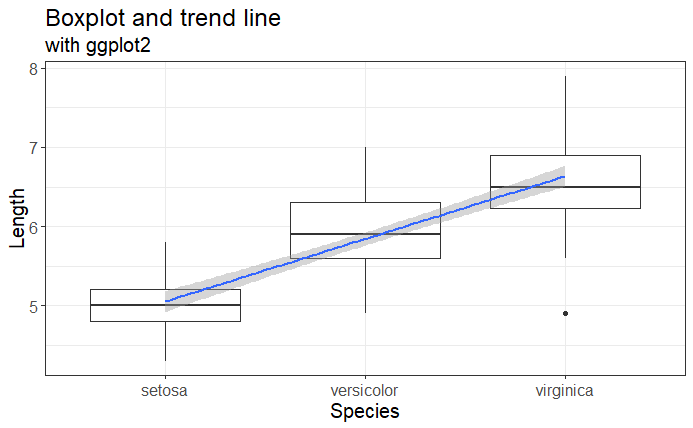

```r
ggplot(data = iris, aes(x = Species, y = Sepal.Length))+
  geom_boxplot() +
  labs(x = "Species", y = "Length", title = "Boxplot and trend line", subtitle="with ggplot2") +
  theme_bw() + theme(text = element_text(size = 15))+
  geom_smooth(aes(x = as.numeric(Species), y = Sepal.Length), method = "lm")
```

Here I have used the variable `Sepal.Length`. You can use any of the additional variables to plot the data.

## 2.4 Correlation tests

### 2.4.1 Basic correlations

We use the function `cor` to obtain the pearson correlation and `cor.test` to run a basic correlation test on our data with significance testing

```r
cor(iris$Sepal.Length, iris$Petal.Length, method = "pearson")
```

```
[1] 0.8717538
```

```r
cor.test(iris$Sepal.Length, iris$Petal.Length)
```

```
    Pearson's product-moment correlation

data:  iris$Sepal.Length and iris$Petal.Length
t = 21.646, df = 148, p-value < 2.2e-16
alternative hypothesis: true correlation is not equal to 0
95 percent confidence interval:
 0.8270363 0.9055080
sample estimates:
      cor
0.8717538
```

#### 2.4.1.1 Up to you

Can you check whether there is a correlation between the `Sepal.Length` and the `Petal.Width`? What about `Petal.Length` and `Petal.Width`?

### 2.4.2 Using the package `psycho`

Above, we did a correlation test on two predictors. We run multiple correlations on multiple predictors with corrections. You can get a table, and a plot. (see here https://www.r-bloggers.com/beautiful-and-powerful-correlation-tables-in-r/amp/)

#### 2.4.2.1 Defaults

```r
## correlation using "psycho"
## use "Alt" + "-" to add "<-"
## use "Ctrl" + "Shift" + "M" to obtain "%>%"
cor <- iris %>%
  correlation()
summary(cor)
```

|  | Sepal.Length | Sepal.Width | Petal.Length |
| --- | --- | --- | --- |
| Sepal.Length |  |  |  |
| Sepal.Width | -0.12 |  |  |
| Petal.Length | 0.87*** | -0.43*** |  |
| Petal.Width | 0.82*** | -0.37*** | 0.96*** |

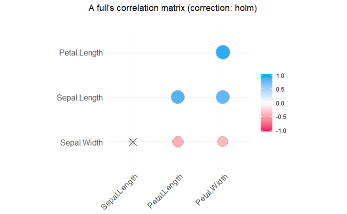

```r
plot(cor)
```

```r
print(cor)
```

```
Pearson Full correlation (p value correction: holm):

   - Sepal.Length / Sepal.Width:   Results of the Pearson correlation showed a non significant small, and negative association between Sepal.Length and Sepal.Width (r(148) = -0.12, p > .1).
   - Sepal.Length / Petal.Length:   Results of the Pearson correlation showed a significant large, and positive association between Sepal.Length and Petal.Length (r(148) = 0.87, p < .001***).
   - Sepal.Width / Petal.Length:   Results of the Pearson correlation showed a significant moderate, and negative association between Sepal.Width and Petal.Length (r(148) = -0.43, p < .001***).
   - Sepal.Length / Petal.Width:   Results of the Pearson correlation showed a significant large, and positive association between Sepal.Length and Petal.Width (r(148) = 0.82, p < .001***).
   - Sepal.Width / Petal.Width:   Results of the Pearson correlation showed a significant moderate, and negative association between Sepal.Width and Petal.Width (r(148) = -0.37, p < .001***).
   - Petal.Length / Petal.Width:   Results of the Pearson correlation showed a significant large, and positive association between Petal.Length and Petal.Width (r(148) = 0.96, p < .001***).
```

#### 2.4.2.2 Changing parameters

You can change the following if you are interested in getting a `spearman` correlation compared to a `pearson` correlation: `method = "spearman"` (method = “pearson”, “spearman”, “kendall”).

The defaults have corrections for multiple comparisons using the `holm` method; you can use `adjust="bonferroni"` to use a bonferroni correction (adjust= “holm” (default), “bonferroni”, “fdr”, “none”)

### 2.4.3 Up to you

Run multiple correlations below by changing the method, or the adjustments. Any comments?

Up to now, we have done some basic summaries and checked the correlations in the data. The pearson correlations we have done provided us with significance levels related to the correlations between two *numeric* outcomes We do not know if the levels of our variable `Species` are statistically different based on one of the predictors. We use inferential statistics here.

## 2.5 First step into statistics

### 2.5.1 Basic t-tests

T.test are used when the outcome (DV) is numeric and the predictor is either numeric or categorical (with two levels only).

#### 2.5.1.1 Numeric predictor

We can run a basic t-test on our data, using the function `t-test`. This looks at the two numeric outcomes and sees if they are different from each other

```r
t.test(iris$Sepal.Length, iris$Petal.Length)
```

```
    Welch Two Sample t-test

data:  iris$Sepal.Length and iris$Petal.Length
t = 13.098, df = 211.54, p-value < 2.2e-16
alternative hypothesis: true difference in means is not equal to 0
95 percent confidence interval:
 1.771500 2.399166
sample estimates:
mean of x mean of y
 5.843333  3.758000
```

#### 2.5.1.2 Categorical predictor

In the `iris` dataset, we have a categorical predictor: `Species` which has three levels

```r
levels(iris$Species)
```

```
[1] "setosa"     "versicolor" "virginica"
```

Let’s subset the data and evaluate the differences between `setosa` and `versicolor` using a t-test and a linear model. We will also check the normality and homogeneity of variance in the data

##### 2.5.1.2.1 Subset

```r
irisSub <- iris %>%
  filter(Species == "setosa" |
           Species == "versicolor")
levels(irisSub$Species)
```

```
[1] "setosa"     "versicolor" "virginica"
```

But wait a minute… We just subsetted the data and our `levels` show three levels factor.. why? Let’s run a summary

```r
summary(irisSub$Species)
```

```
    setosa versicolor  virginica
        50         50          0
```

Aha! So the subsetting worked as the `virginica` cases are 0. We need to tell `R` to change the factor levels

```r
irisSub$Species <- factor(irisSub$Species)
levels(irisSub$Species)
```

```
[1] "setosa"     "versicolor"
```

Now this works better

##### 2.5.1.2.2 Normality of distribution

###### 2.5.1.2.2.1 Shapiro test

To check normality of distribution, we use the `shapiro.test` on the numeric outcome. Given that our predictor now has two levels. We need to subset the data again to check normality of the outcome `Sepal.Length` for each level of our factor `Species`

```r
irisSubSet <- iris %>%
  filter(Species == "setosa")
irisSubVers <- iris %>%
  filter(Species == "versicolor")

shapiro.test(irisSubSet$Sepal.Length)
```

```
    Shapiro-Wilk normality test

data:  irisSubSet$Sepal.Length
W = 0.9777, p-value = 0.4595
```

```r
shapiro.test(irisSubVers$Sepal.Length)
```

```
    Shapiro-Wilk normality test

data:  irisSubVers$Sepal.Length
W = 0.97784, p-value = 0.4647
```

How to interpret this non-statistically significant result? This tells us that the distribution of the data is not statistically different from a normal distribution.

###### 2.5.1.2.2.2 Density plot

We can also use a density plot to evaluate normality. The results show that both levels have bell shaped distributions.

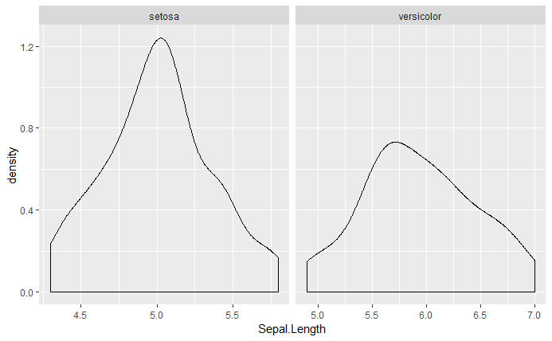

```r
irisSub %>%
  ggplot(aes(x = Sepal.Length))+
  geom_density()+
  facet_wrap(~Species, scales = "free_x")
```

##### 2.5.1.2.3 Homogeneity of variance

Because our data is normally distributed, we can use the `barlett` test. If our data were non-normally distributed, we would use the leveneTest. We can check both.

###### 2.5.1.2.3.1 Barlett test

```r
bartlett.test(Sepal.Length ~ Species, data = irisSub)
```

```
    Bartlett test of homogeneity of variances

data:  Sepal.Length by Species
Bartlett's K-squared = 6.8917, df = 1, p-value = 0.00866
```

###### 2.5.1.2.3.2 Levene test

```r
var.test(Sepal.Length ~ Species, data = irisSub)
```

```
    F test to compare two variances

data:  Sepal.Length by Species
F = 0.46634, num df = 49, denom df = 49, p-value = 0.008657
alternative hypothesis: true ratio of variances is not equal to 1
95 percent confidence interval:
 0.2646385 0.8217841
sample estimates:
ratio of variances
         0.4663429
```

```r
car::leveneTest(Sepal.Length ~ Species, data = irisSub)
```

```
Levene's Test for Homogeneity of Variance (center = median)
      Df F value   Pr(>F)
group  1  8.1727 0.005196 **
      98
---
Signif. codes:  0 ‘***’ 0.001 ‘**’ 0.01 ‘*’ 0.05 ‘.’ 0.1 ‘ ’ 1
```

In all cases, the statistically significant result indicates that there is evidence that the variance of two levels of the factor `Species` is statistically significant; i.e., the variances are not equal

##### 2.5.1.2.4 T-test

We then run a t-test on the data. We specify the formula as `y ~ x` and add `var.equal = FALSE`

```r
t.test(Sepal.Length ~ Species, data = irisSub, var.equal = FALSE)
```

```
    Welch Two Sample t-test

data:  Sepal.Length by Species
t = -10.521, df = 86.538, p-value < 2.2e-16
alternative hypothesis: true difference in means is not equal to 0
95 percent confidence interval:
 -1.1057074 -0.7542926
sample estimates:
    mean in group setosa mean in group versicolor
                   5.006                    5.936
```

To interpret the t-test, we say that there is evidence for a statistically significant difference between the two groups: `setosa` and `versicolor`: `t(86) = -10.521, p < 2.2e-16`. The mean of `setosa` is significantly lower than that of `versicolor`.

##### 2.5.1.2.5 Linear Model

Let us run a linear model on the same data

```r
summary(lm(Sepal.Length ~ Species, data = irisSub))
```

```
Call:
lm(formula = Sepal.Length ~ Species, data = irisSub)

Residuals:
    Min      1Q  Median      3Q     Max
-1.0360 -0.3135 -0.0060  0.2715  1.0640

Coefficients:
                  Estimate Std. Error t value Pr(>|t|)
(Intercept)        5.00600    0.06250   80.09   <2e-16 ***
Speciesversicolor  0.93000    0.08839   10.52   <2e-16 ***
---
Signif. codes:  0 ‘***’ 0.001 ‘**’ 0.01 ‘*’ 0.05 ‘.’ 0.1 ‘ ’ 1

Residual standard error: 0.442 on 98 degrees of freedom
Multiple R-squared:  0.5304,    Adjusted R-squared:  0.5256
F-statistic: 110.7 on 1 and 98 DF,  p-value: < 2.2e-16
```

Any comments? discuss with your neighbour.

The results of the linear model are exactly the same, albeit with a difference in the sign of the difference. This indicates that the $\beta$ coefficient for `versicolor` is significantly higher than that of `setosa` by `0.93000`: `t(98) = 10.52, p < <2e-16`.

The dataset `iris` contains three species. We will run an ANOVA and a linear model on the data.

### 2.5.2 Basic ANOVA

We can use the function `aov` to run an Analysis of Variance

```r
mdl.aov <- aov(Sepal.Length ~ Species, data = iris)
summary(mdl.aov)
```

```
             Df Sum Sq Mean Sq F value Pr(>F)
Species       2  63.21  31.606   119.3 <2e-16 ***
Residuals   147  38.96   0.265
---
Signif. codes:  0 ‘***’ 0.001 ‘**’ 0.01 ‘*’ 0.05 ‘.’ 0.1 ‘ ’ 1
```

### 2.5.3 Linear model

We can use the function `lm` to run a linear model

```r
mdl.lm <- lm(Sepal.Length ~ Species, data = iris)
summary(mdl.lm)
```

```
Call:
lm(formula = Sepal.Length ~ Species, data = iris)

Residuals:
    Min      1Q  Median      3Q     Max
-1.6880 -0.3285 -0.0060  0.3120  1.3120

Coefficients:
                  Estimate Std. Error t value Pr(>|t|)
(Intercept)         5.0060     0.0728  68.762  < 2e-16 ***
Speciesversicolor   0.9300     0.1030   9.033 8.77e-16 ***
Speciesvirginica    1.5820     0.1030  15.366  < 2e-16 ***
---
Signif. codes:  0 ‘***’ 0.001 ‘**’ 0.01 ‘*’ 0.05 ‘.’ 0.1 ‘ ’ 1

Residual standard error: 0.5148 on 147 degrees of freedom
Multiple R-squared:  0.6187,    Adjusted R-squared:  0.6135
F-statistic: 119.3 on 2 and 147 DF,  p-value: < 2.2e-16
```

But wait… How is the linear model comparable to the analysis of variance we ran above? This linear model derives the analysis of variance we saw above, use `anova` on your linear model..

Here are the results of the initial Analysis of variance:

```r
summary(mdl.aov)
```

```
             Df Sum Sq Mean Sq F value Pr(>F)
Species       2  63.21  31.606   119.3 <2e-16 ***
Residuals   147  38.96   0.265
---
Signif. codes:  0 ‘***’ 0.001 ‘**’ 0.01 ‘*’ 0.05 ‘.’ 0.1 ‘ ’ 1
```

And here are the results of the linear model with the `anova` function

```r
anova(mdl.lm)
```

```
Analysis of Variance Table

Response: Sepal.Length
           Df Sum Sq Mean Sq F value    Pr(>F)
Species     2 63.212  31.606  119.26 < 2.2e-16 ***
Residuals 147 38.956   0.265
---
Signif. codes:  0 ‘***’ 0.001 ‘**’ 0.01 ‘*’ 0.05 ‘.’ 0.1 ‘ ’ 1
```

They are exactly the same… The underlying of an Analysis of variance is a linear model. We will continue with a linear model to understand it better

## 2.6 Looking again at our Linear Model

The basic assumption of a Linear model is to create a regression analysis on the data. We have an outcome (or dependent variable) and a predictor (or an independent variable). The formula of a linear model is as follows `outcome~predictor` that can be read as “outcome as a function of the predictor”. We can add “1” to specify an intercept, but this is by default added to the model

### 2.6.1 Model estimation

```r
mdl.lm <- lm(Sepal.Length ~ Species, data = iris)
# same as below.
#mdl.lm <- lm(Sepal.Length~1+Species, data=iris)
mdl.lm#also print(mdl.lm)
```

```
Call:
lm(formula = Sepal.Length ~ Species, data = iris)

Coefficients:
      (Intercept)  Speciesversicolor   Speciesvirginica
            5.006              0.930              1.582
```

```r
summary(mdl.lm)
```

```
Call:
lm(formula = Sepal.Length ~ Species, data = iris)

Residuals:
    Min      1Q  Median      3Q     Max
-1.6880 -0.3285 -0.0060  0.3120  1.3120

Coefficients:
                  Estimate Std. Error t value Pr(>|t|)
(Intercept)         5.0060     0.0728  68.762  < 2e-16 ***
Speciesversicolor   0.9300     0.1030   9.033 8.77e-16 ***
Speciesvirginica    1.5820     0.1030  15.366  < 2e-16 ***
---
Signif. codes:  0 ‘***’ 0.001 ‘**’ 0.01 ‘*’ 0.05 ‘.’ 0.1 ‘ ’ 1

Residual standard error: 0.5148 on 147 degrees of freedom
Multiple R-squared:  0.6187,    Adjusted R-squared:  0.6135
F-statistic: 119.3 on 2 and 147 DF,  p-value: < 2.2e-16
```

### 2.6.2 Tidying the output

```r
# from library(broom)
tidy(mdl.lm) %>%
  select(term, estimate) %>%
  mutate(estimate = round(estimate, 3))
```

| term | estimate |
| --- | --- |
| (Intercept) | 5.006 |
| Speciesversicolor | 0.930 |
| Speciesvirginica | 1.582 |

```r
mycoef <- tidy(mdl.lm) %>% pull(estimate)
```

### 2.6.3 Obtaining our “true” coefficients

But where are our actual values based on the means in the table above? We run a model that suppresses the intercept (i.e., adding 0 instead of 1) and this will allow us to obtain the “true” coefficients for each level of our predictor

```r
mdl.lm.2 <- lm(Sepal.Length ~ 0 + Species, data = iris)
summary(mdl.lm.2)
```

```
Call:
lm(formula = Sepal.Length ~ 0 + Species, data = iris)

Residuals:
    Min      1Q  Median      3Q     Max
-1.6880 -0.3285 -0.0060  0.3120  1.3120

Coefficients:
                  Estimate Std. Error t value Pr(>|t|)
Speciessetosa       5.0060     0.0728   68.76   <2e-16 ***
Speciesversicolor   5.9360     0.0728   81.54   <2e-16 ***
Speciesvirginica    6.5880     0.0728   90.49   <2e-16 ***
---
Signif. codes:  0 ‘***’ 0.001 ‘**’ 0.01 ‘*’ 0.05 ‘.’ 0.1 ‘ ’ 1

Residual standard error: 0.5148 on 147 degrees of freedom
Multiple R-squared:  0.9925,    Adjusted R-squared:  0.9924
F-statistic:  6522 on 3 and 147 DF,  p-value: < 2.2e-16
```

### 2.6.4 Plot

Looking back at our plot

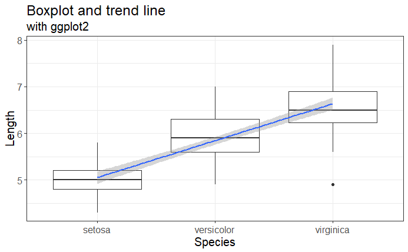

```r
ggplot(data = iris, aes(x = Species, y = Sepal.Length))+
  geom_boxplot() +
  labs(x = "Species", y = "Length", title = "Boxplot and trend line", subtitle = "with ggplot2") +
  theme_bw() + theme(text = element_text(size = 15))+
  geom_smooth(aes(x = as.numeric(Species), y = Sepal.Length), method = "lm")
```

```r
#Setosa
mycoef[1]
```

```
[1] 5.006
```

```r
#Versicolor
mycoef[1] + mycoef[2]
```

```
[1] 5.936
```

```r
#Virginica
mycoef[1] + mycoef[3]
```

```
[1] 6.588
```

The same as

```r
tidy(mdl.lm.2) %>%
  select(term, estimate) %>%
  mutate(estimate = round(estimate, 3))
```

| term | estimate |
| --- | --- |
| Speciessetosa | 5.006 |
| Speciesversicolor | 5.936 |
| Speciesvirginica | 6.588 |

```r
mycoef <- tidy(mdl.lm.2) %>% pull(estimate)

#Setosa
mycoef[1]
```

```
[1] 5.006
```

```r
#Versicolor
mycoef[2]
```

```
[1] 5.936
```

```r
#Virginica
mycoef[3]
```

```
[1] 6.588
```

### 2.6.5 Dissecting the model

Let us dissect the model. If you use “str”, you will be able to see what is available under our linear model. To access some info from the model

#### 2.6.5.1 “str” and “coef”

```r
str(mdl.lm)
```

```
List of 13
 $ coefficients : Named num [1:3] 5.01 0.93 1.58
  ..- attr(*, "names")= chr [1:3] "(Intercept)" "Speciesversicolor" "Speciesvirginica"
 $ residuals    : Named num [1:150] 0.094 -0.106 -0.306 -0.406 -0.006 ...
  ..- attr(*, "names")= chr [1:150] "1" "2" "3" "4" ...
 $ effects      : Named num [1:150] -71.5659 0.8025 7.91 -0.3826 0.0174 ...
  ..- attr(*, "names")= chr [1:150] "(Intercept)" "Speciesversicolor" "Speciesvirginica" "" ...
 $ rank         : int 3
 $ fitted.values: Named num [1:150] 5.01 5.01 5.01 5.01 5.01 ...
  ..- attr(*, "names")= chr [1:150] "1" "2" "3" "4" ...
 $ assign       : int [1:3] 0 1 1
 $ qr           :List of 5
  ..$ qr   : num [1:150, 1:3] -12.2474 0.0816 0.0816 0.0816 0.0816 ...
  .. ..- attr(*, "dimnames")=List of 2
  .. .. ..$ : chr [1:150] "1" "2" "3" "4" ...
  .. .. ..$ : chr [1:3] "(Intercept)" "Speciesversicolor" "Speciesvirginica"
  .. ..- attr(*, "assign")= int [1:3] 0 1 1
  .. ..- attr(*, "contrasts")=List of 1
  .. .. ..$ Species: chr "contr.treatment"
  ..$ qraux: num [1:3] 1.08 1.05 1.09
  ..$ pivot: int [1:3] 1 2 3
  ..$ tol  : num 1e-07
  ..$ rank : int 3
  ..- attr(*, "class")= chr "qr"
 $ df.residual  : int 147
 $ contrasts    :List of 1
  ..$ Species: chr "contr.treatment"
 $ xlevels      :List of 1
  ..$ Species: chr [1:3] "setosa" "versicolor" "virginica"
 $ call         : language lm(formula = Sepal.Length ~ Species, data = iris)
 $ terms        :Classes 'terms', 'formula'  language Sepal.Length ~ Species
  .. ..- attr(*, "variables")= language list(Sepal.Length, Species)
  .. ..- attr(*, "factors")= int [1:2, 1] 0 1
  .. .. ..- attr(*, "dimnames")=List of 2
  .. .. .. ..$ : chr [1:2] "Sepal.Length" "Species"
  .. .. .. ..$ : chr "Species"
  .. ..- attr(*, "term.labels")= chr "Species"
  .. ..- attr(*, "order")= int 1
  .. ..- attr(*, "intercept")= int 1
  .. ..- attr(*, "response")= int 1
  .. ..- attr(*, ".Environment")=<environment: R_GlobalEnv>
  .. ..- attr(*, "predvars")= language list(Sepal.Length, Species)
  .. ..- attr(*, "dataClasses")= Named chr [1:2] "numeric" "factor"
  .. .. ..- attr(*, "names")= chr [1:2] "Sepal.Length" "Species"
 $ model        :'data.frame':  150 obs. of  2 variables:
  ..$ Sepal.Length: num [1:150] 5.1 4.9 4.7 4.6 5 5.4 4.6 5 4.4 4.9 ...
  ..$ Species     : Factor w/ 3 levels "setosa","versicolor",..: 1 1 1 1 1 1 1 1 1 1 ...
  ..- attr(*, "terms")=Classes 'terms', 'formula'  language Sepal.Length ~ Species
  .. .. ..- attr(*, "variables")= language list(Sepal.Length, Species)
  .. .. ..- attr(*, "factors")= int [1:2, 1] 0 1
  .. .. .. ..- attr(*, "dimnames")=List of 2
  .. .. .. .. ..$ : chr [1:2] "Sepal.Length" "Species"
  .. .. .. .. ..$ : chr "Species"
  .. .. ..- attr(*, "term.labels")= chr "Species"
  .. .. ..- attr(*, "order")= int 1
  .. .. ..- attr(*, "intercept")= int 1
  .. .. ..- attr(*, "response")= int 1
  .. .. ..- attr(*, ".Environment")=<environment: R_GlobalEnv>
  .. .. ..- attr(*, "predvars")= language list(Sepal.Length, Species)
  .. .. ..- attr(*, "dataClasses")= Named chr [1:2] "numeric" "factor"
  .. .. .. ..- attr(*, "names")= chr [1:2] "Sepal.Length" "Species"
 - attr(*, "class")= chr "lm"
```

```r
coef(mdl.lm)
```

```
      (Intercept) Speciesversicolor  Speciesvirginica
            5.006             0.930             1.582
```

```r
## same as
## mdl.lm$coefficients
```

#### 2.6.5.2 “coef” and “coefficients”

What if I want to obtain the “Intercept”? Or the coefficient for distance? What if I want the full row for distance?

```r
coef(mdl.lm)[1] # same as mdl.lm$coefficients[1]
```

```
(Intercept)
      5.006
```

```r
coef(mdl.lm)[2] # same as mdl.lm$coefficients[2]
```

```
Speciesversicolor
             0.93
```

```r
summary(mdl.lm)$coefficients[2, ] # full row
```

```
    Estimate   Std. Error      t value     Pr(>|t|)
9.300000e-01 1.029579e-01 9.032819e+00 8.770194e-16
```

```r
summary(mdl.lm)$coefficients[2, 4] #for p value
```

```
[1] 8.770194e-16
```

#### 2.6.5.3 Up to you

Play around with the model summary and obtain the t values for the three levels. You can do this by referring to the coefficient as above

What about residuals (difference between the observed value and the estimated value of the quantity) and fitted values?

```r
residuals(mdl.lm)
```

```
     1      2      3      4      5      6      7      8      9
 0.094 -0.106 -0.306 -0.406 -0.006  0.394 -0.406 -0.006 -0.606
    10     11     12     13     14     15     16     17     18
-0.106  0.394 -0.206 -0.206 -0.706  0.794  0.694  0.394  0.094
    19     20     21     22     23     24     25     26     27
 0.694  0.094  0.394  0.094 -0.406  0.094 -0.206 -0.006 -0.006
    28     29     30     31     32     33     34     35     36
 0.194  0.194 -0.306 -0.206  0.394  0.194  0.494 -0.106 -0.006
    37     38     39     40     41     42     43     44     45
 0.494 -0.106 -0.606  0.094 -0.006 -0.506 -0.606 -0.006  0.094
    46     47     48     49     50     51     52     53     54
-0.206  0.094 -0.406  0.294 -0.006  1.064  0.464  0.964 -0.436
    55     56     57     58     59     60     61     62     63
 0.564 -0.236  0.364 -1.036  0.664 -0.736 -0.936 -0.036  0.064
    64     65     66     67     68     69     70     71     72
 0.164 -0.336  0.764 -0.336 -0.136  0.264 -0.336 -0.036  0.164
    73     74     75     76     77     78     79     80     81
 0.364  0.164  0.464  0.664  0.864  0.764  0.064 -0.236 -0.436
    82     83     84     85     86     87     88     89     90
-0.436 -0.136  0.064 -0.536  0.064  0.764  0.364 -0.336 -0.436
    91     92     93     94     95     96     97     98     99
-0.436  0.164 -0.136 -0.936 -0.336 -0.236 -0.236  0.264 -0.836
   100    101    102    103    104    105    106    107    108
-0.236 -0.288 -0.788  0.512 -0.288 -0.088  1.012 -1.688  0.712
   109    110    111    112    113    114    115    116    117
 0.112  0.612 -0.088 -0.188  0.212 -0.888 -0.788 -0.188 -0.088
   118    119    120    121    122    123    124    125    126
 1.112  1.112 -0.588  0.312 -0.988  1.112 -0.288  0.112  0.612
   127    128    129    130    131    132    133    134    135
-0.388 -0.488 -0.188  0.612  0.812  1.312 -0.188 -0.288 -0.488
   136    137    138    139    140    141    142    143    144
 1.112 -0.288 -0.188 -0.588  0.312  0.112  0.312 -0.788  0.212
   145    146    147    148    149    150
 0.112  0.112 -0.288 -0.088 -0.388 -0.688
```

```r
fitted(mdl.lm)
```

```
    1     2     3     4     5     6     7     8     9    10    11
5.006 5.006 5.006 5.006 5.006 5.006 5.006 5.006 5.006 5.006 5.006
   12    13    14    15    16    17    18    19    20    21    22
5.006 5.006 5.006 5.006 5.006 5.006 5.006 5.006 5.006 5.006 5.006
   23    24    25    26    27    28    29    30    31    32    33
5.006 5.006 5.006 5.006 5.006 5.006 5.006 5.006 5.006 5.006 5.006
   34    35    36    37    38    39    40    41    42    43    44
5.006 5.006 5.006 5.006 5.006 5.006 5.006 5.006 5.006 5.006 5.006
   45    46    47    48    49    50    51    52    53    54    55
5.006 5.006 5.006 5.006 5.006 5.006 5.936 5.936 5.936 5.936 5.936
   56    57    58    59    60    61    62    63    64    65    66
5.936 5.936 5.936 5.936 5.936 5.936 5.936 5.936 5.936 5.936 5.936
   67    68    69    70    71    72    73    74    75    76    77
5.936 5.936 5.936 5.936 5.936 5.936 5.936 5.936 5.936 5.936 5.936
   78    79    80    81    82    83    84    85    86    87    88
5.936 5.936 5.936 5.936 5.936 5.936 5.936 5.936 5.936 5.936 5.936
   89    90    91    92    93    94    95    96    97    98    99
5.936 5.936 5.936 5.936 5.936 5.936 5.936 5.936 5.936 5.936 5.936
  100   101   102   103   104   105   106   107   108   109   110
5.936 6.588 6.588 6.588 6.588 6.588 6.588 6.588 6.588 6.588 6.588
  111   112   113   114   115   116   117   118   119   120   121
6.588 6.588 6.588 6.588 6.588 6.588 6.588 6.588 6.588 6.588 6.588
  122   123   124   125   126   127   128   129   130   131   132
6.588 6.588 6.588 6.588 6.588 6.588 6.588 6.588 6.588 6.588 6.588
  133   134   135   136   137   138   139   140   141   142   143
6.588 6.588 6.588 6.588 6.588 6.588 6.588 6.588 6.588 6.588 6.588
  144   145   146   147   148   149   150
6.588 6.588 6.588 6.588 6.588 6.588 6.588
```

#### 2.6.5.4 Goodness of fit?

```r
AIC(mdl.lm) # Akaike's Information Criterion, lower values are better
```

```
[1] 231.452
```

```r
BIC(mdl.lm) # Bayesian AIC
```

```
[1] 243.4945
```

```r
logLik(mdl.lm)  # log likelihood
```

```
'log Lik.' -111.726 (df=4)
```

Or use the following from `broom`

```r
glance(mdl.lm)
```

| r.squared | adj.r.squared | sigma | statistic | p.value | df | logLik | AIC | BIC | deviance | df.residual |
| --- | --- | --- | --- | --- | --- | --- | --- | --- | --- | --- |
| 0.6187057 | 0.6135181 | 0.5147894 | 119.2645 | 1.669669e-31 | 3 | -111.726 | 231.452 | 243.4945 | 38.9562 | 147 |

#### 2.6.5.5 Significance testing

Are the above informative? of course not directly. If we want to test for overall significance of model. We run a null model (aka intercept only) and compare models.

```r
mdl.lm.Null <- lm(Sepal.Length ~ 1, data=iris)
mdl.comp <- anova(mdl.lm.Null, mdl.lm)
mdl.comp
```

```
Analysis of Variance Table

Model 1: Sepal.Length ~ 1
Model 2: Sepal.Length ~ Species
  Res.Df     RSS Df Sum of Sq      F    Pr(>F)
1    149 102.168
2    147  38.956  2    63.212 119.26 < 2.2e-16 ***
---
Signif. codes:  0 ‘***’ 0.001 ‘**’ 0.01 ‘*’ 0.05 ‘.’ 0.1 ‘ ’ 1
```

The results show that adding the factor “Species” improves the model fit. We can write this as follows: Model comparison showed that the addition of Species improved the model fit when compared with an intercept only model ($F$(2) = 119.26, *p* < 1.669669210^{-31})

#### 2.6.5.6 Plotting fitted values

##### 2.6.5.6.1 Trend line

Let’s plot our fitted values but only for the trend line

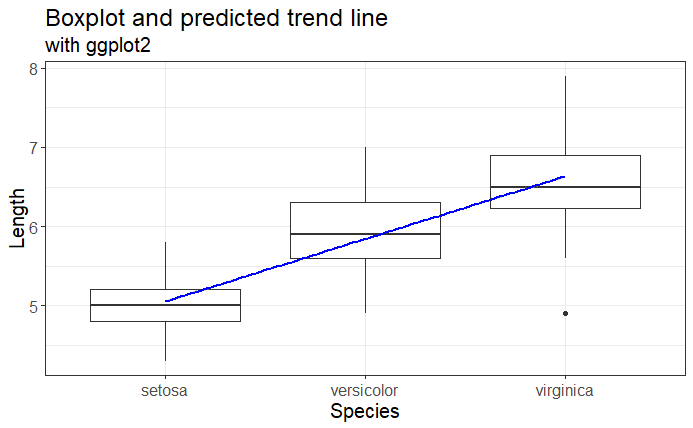

```r
ggplot(data = iris, aes(x = Species, y = Sepal.Length))+
  geom_boxplot() +
  labs(x = "Species", y = "Length", title = "Boxplot and predicted trend line", subtitle = "with ggplot2") +
  theme_bw() + theme(text = element_text(size = 15))+
  geom_smooth(aes(x = as.numeric(Species), y = predict(mdl.lm)), method = "lm", color = "blue")
```

This allows us to plot the fitted values from our model with the predicted linear trend. This is exactly the same as our original data.

##### 2.6.5.6.2 Predicted means and the trend line

We can also plot the predicted means and linear trend

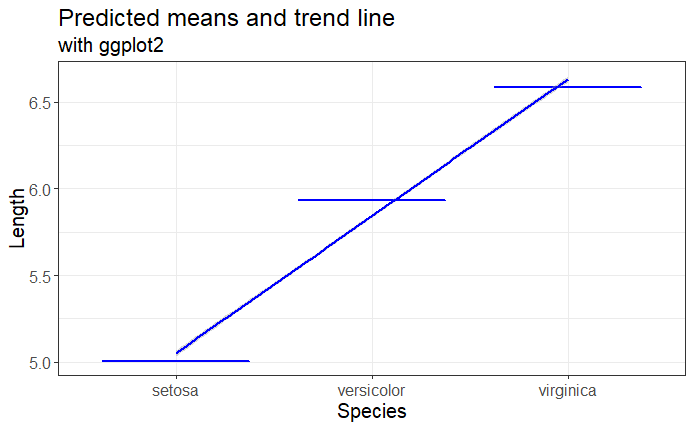

```r
ggplot(data = iris, aes(x = Species, y = predict(mdl.lm)))+
  geom_boxplot(color = "blue") +
  labs(x = "Species", y = "Length", title = "Predicted means and trend line", subtitle = "with ggplot2") +
  theme_bw() + theme(text = element_text(size = 15))+
  geom_smooth(aes(x = as.numeric(Species), y = predict(mdl.lm)), method = "lm", color = "blue")
```

##### 2.6.5.6.3 Raw data, predicted means and the trend line

We can also plot the actual data, the predicted means and linear trend

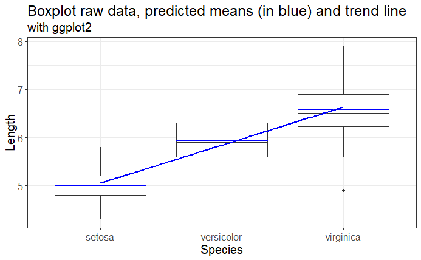

```r
ggplot(data = iris, aes(x = Species, y = Sepal.Length))+
  geom_boxplot()+
  geom_boxplot(aes(x = Species, y = predict(mdl.lm)), color = "blue") +
  labs(x = "Species", y = "Length", title = "Boxplot raw data, predicted means (in blue) and trend line", subtitle = "with ggplot2") +
  theme_bw() + theme(text = element_text(size = 15))+
  geom_smooth(aes(x = as.numeric(Species), y = predict(mdl.lm)), method = "lm", color = "blue")
```

### 2.6.6 What about pairwise comparison?

Based on our model’s summary, can you tell me if there is a difference between Versicolor and Virginica?

```r
summary(mdl.lm)
```

```
Call:
lm(formula = Sepal.Length ~ Species, data = iris)

Residuals:
    Min      1Q  Median      3Q     Max
-1.6880 -0.3285 -0.0060  0.3120  1.3120

Coefficients:
                  Estimate Std. Error t value Pr(>|t|)
(Intercept)         5.0060     0.0728  68.762  < 2e-16 ***
Speciesversicolor   0.9300     0.1030   9.033 8.77e-16 ***
Speciesvirginica    1.5820     0.1030  15.366  < 2e-16 ***
---
Signif. codes:  0 ‘***’ 0.001 ‘**’ 0.01 ‘*’ 0.05 ‘.’ 0.1 ‘ ’ 1

Residual standard error: 0.5148 on 147 degrees of freedom
Multiple R-squared:  0.6187,    Adjusted R-squared:  0.6135
F-statistic: 119.3 on 2 and 147 DF,  p-value: < 2.2e-16
```

```r
emmeans(mdl.lm, pairwise ~ Species, adjust = "fdr")
```

```
$emmeans
 Species    emmean     SE  df lower.CL upper.CL
 setosa       5.01 0.0728 147     4.86     5.15
 versicolor   5.94 0.0728 147     5.79     6.08
 virginica    6.59 0.0728 147     6.44     6.73

Confidence level used: 0.95

$contrasts
 contrast               estimate    SE  df t.ratio p.value
 setosa - versicolor      -0.930 0.103 147  -9.033 <.0001
 setosa - virginica       -1.582 0.103 147 -15.366 <.0001
 versicolor - virginica   -0.652 0.103 147  -6.333 <.0001

P value adjustment: fdr method for 3 tests
```

How to interpret the output? Discuss with your neighbour and share with the group.

Hint… Look at the emmeans values for each level of our factor “Species” and the contrasts.